# Introduction to Diversification

## Simulating Trees

The purpose of this section is to introduce you to the simulation of evolutionary trees and the use of likelihood and AIC scores to compare model fit. There are many packages available for simulating trees. Lets start with the simplest process: pure birth.

```r
setwd("/Users/michael_alfaro/Dropbox/teaching/200a 2015/tree-sims-lab/") #you need to change this to match your directory")
library(geiger)
library(phytools)
library(diversitree)
```

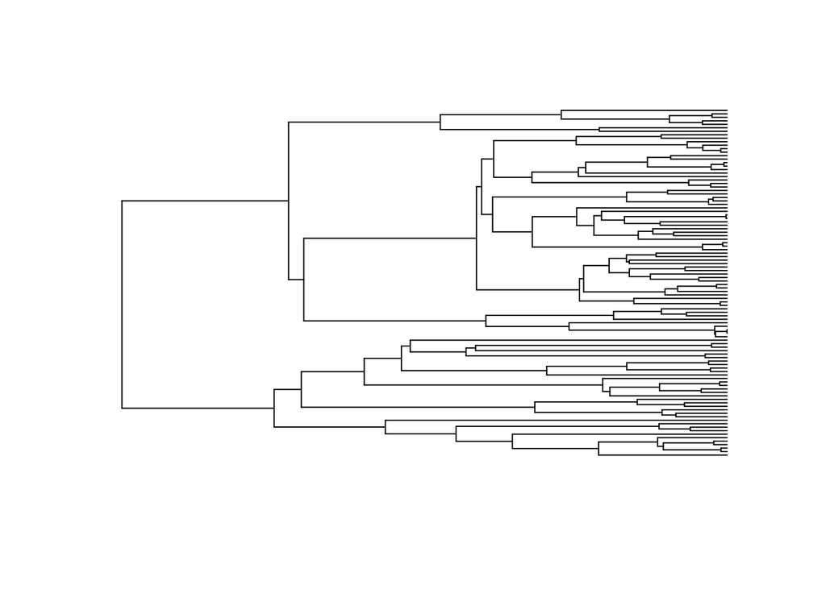

```r
source('rabosky_functions.R')

# Using function simulateTree to simulate a birth death tree:
# Example, lambda = 10, mu = 5
pars <- c(10, 0); #in order: lambda, mu
tt <- simulateTree(pars, max.taxa=100)

##simulate under BD and fit gamma
## is confidence in speciation or extinction better?
## regression
## show loop construct
## pull lambda and mu

plot(tt,  show.tip.label = F)
```

What have we done? Using functions in diversitree we specify parameters for a birth death tree (with the pars() function). Next we use the function simulateTree to make a tree with those parameters. We can now FIT a birth-death model to this tree. Here we know the true speciation and extinction rates. Lets see how well we can estimate those from a tree with 100 tips. To fit a model to a tree in diversitree we have to 1) create a likelihood function based on the tree and 2) pass that funciton to another function called fitDiversitree().

```r
# use function diversitree::make.bd
# fit model with fitDiversitree
# Example:
#   my_likelihood_fxn <- make.bd(....)

tt.func <- make.bd(tt)
fitDiversitree(tt.func)
```

```
## $pars
##    lambda        mu
## 12.747185  4.228752
##
## $loglik
## [1] 492.623
##
## $AIC
## [1] -981.246
##
## $counts
## function gradient
##       15       15
##
## $convergence
## [1] 0
##
## $message
## [1] "CONVERGENCE: REL_REDUCTION_OF_F <= FACTR*EPSMCH"
```

What values of lambda and mu did you get? How do these compare to your original simulation?

## Exercise 1: Can we estimate speciation and extinction with confidence?

Simulate 100 trees with the same birth and death rate (use a non-zero death rate). Fit a birth-death model to each tree. Extract the estimated birth and death rates and plot a histogram from your sample and comment on how well the estimates compare to the true values. What does this imply about what we can learn from empirical studies of molecular phylogenies about diversification? Here is some pseudocode to get you started.

```r
# General template for simulations:
# In this example, we will just
#  generate a single random number
#  for each replicate simulation, then
#  store the results in a vector.

REPS <- 5
myResults <- numeric(REPS)
for (i in 1:REPS){

#  Here we would do the simulation:
    tmp <- rnorm(1)

#   tmp is now the result of our simulation.
#   We will now store it in the results vector:

    myResults[i] <- tmp

}
```

## Exercise 2: How much variation is there in a birth-death process?

Simulate 100 trees under a constant rate of birth and death. Extract the number of species from each tree. Create a histogram of the resulting distribution. How much stochasticity is associated with the outcome of a birth-death process? What does this suggest about our ability to intuitively identify clades that have undergone exceptional speciation?

More pseudocode to help you get started….

```r
# Uncomment the appropriate lines below
#  and fill in the appropriate functions

REPS <- 5
taxon_count <- numeric(REPS)

for (i in 1:REPS){

#   tree <-
#   taxon_count[i] <-

}

#    taxon_count is now a vector
#     of richness: you can plot a histogram
#     with function hist(...)
#     compute mean, quantile, etc.
```

## Lineage through time plots

If the speciation rate is constant over time we expect that lineages will accumulate in a log-linear fashion. We can visualize this with the ltt() function.

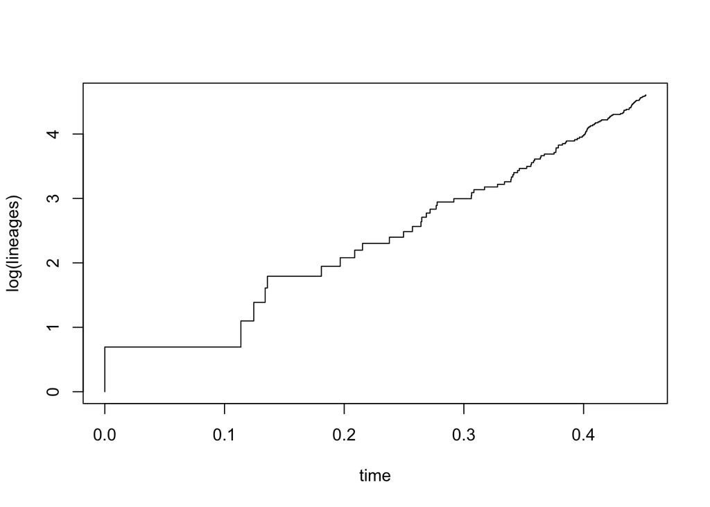

```
## Object of class "ltt" containing:
##
## (1) A phylogenetic tree with 100 tips and 99 internal nodes.
##
## (2) Vectors containing the number of lineages (ltt) and branching times (times) on the tree.
##
## (3) A value for Pybus & Harvey's "gamma" statistic of 1.0867, p-value = 0.2772.
```

Now lets take a look at a simulation where the extinct taxa are retained.

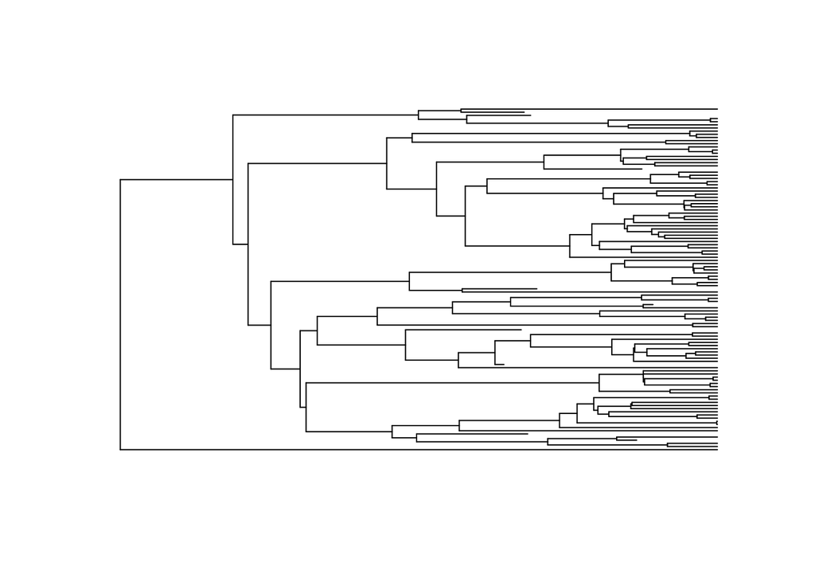

```r
##
pars <- c(10, 5); #in order: lambda, mu
tt <- simulateTree(pars, max.taxa=100)
ttEx <- sim.bdtree(b = 10, d = 1, stop = "taxa", t = 100, n = 100 )
plot(ttEx, show.tip.label = F)
```

You can see that this function tracks all species that went extinct over the course of the simulation. We can prune these extinct taxa.

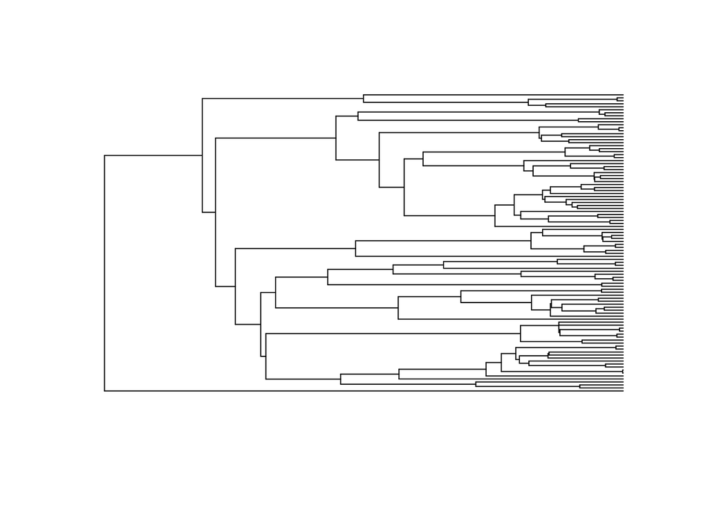

```r
livingOnly <- drop.fossil(ttEx)
plot(livingOnly, show.tip.label = F)
```

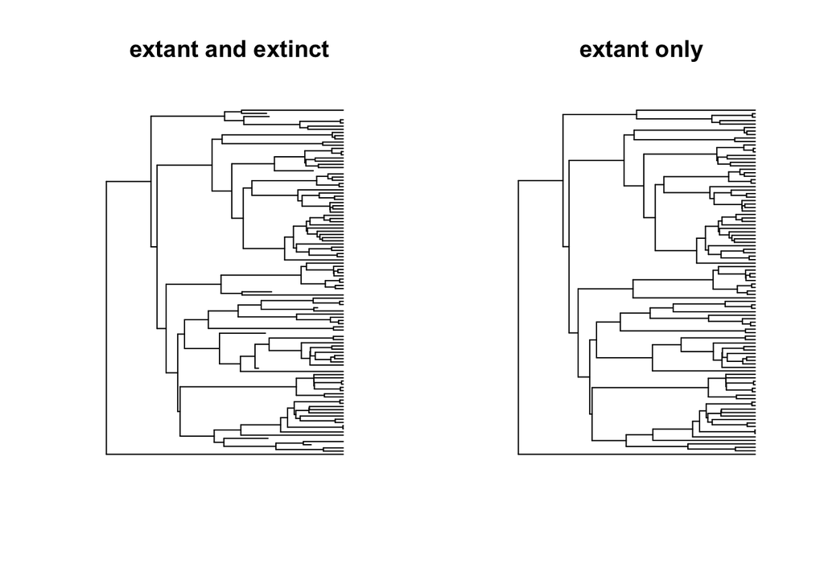

```r
par(mfrow = c(1,2))
plot(ttEx, show.tip.label = F, main = "extant and extinct")
plot(livingOnly, show.tip.label = F, main = "extant only")
```

## Exercise 3. What does extinction do to the shape of the tree?

Simulate 5 trees with and without extinction that have similar net diversification rates. Can you say anything about the general shape of the trees that have been simulated with extinction?

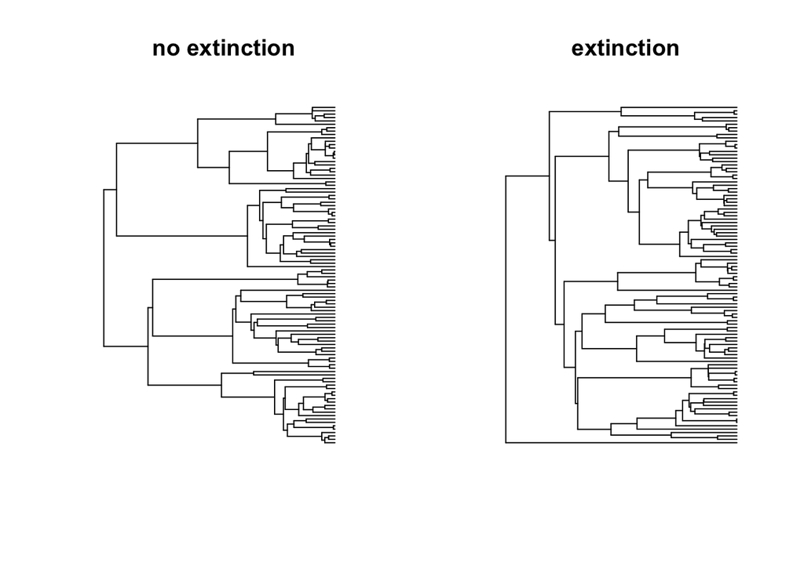

```r
par(mfrow = c(1,2))
plot(tt, show.tip.label = F, main = "no extinction")
plot(livingOnly, show.tip.label = F, main = "extinction")
```

[output not shown]

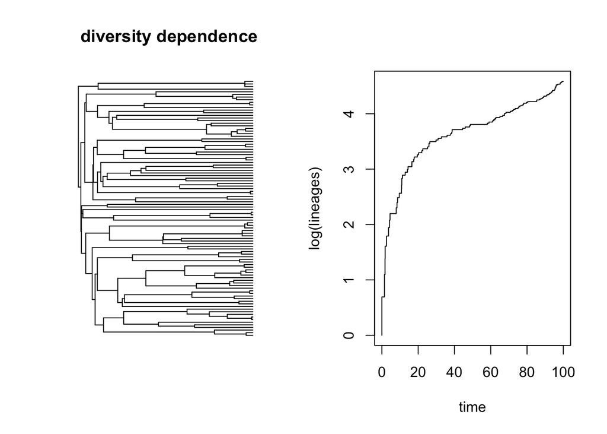

```
## Object of class "ltt" containing:
##
## (1) A phylogenetic tree with 98 tips and 97 internal nodes.
##
## (2) Vectors containing the number of lineages (ltt) and branching times (times) on the tree.
##
## (3) A value for Pybus & Harvey's "gamma" statistic of -2.1838, p-value = 0.029.
```

```r
ddTree <- dd_sim(c(0.12,0.02,100),100)
#note that ddTree is a list. The tree with extinct members pruned is element 2
ddLivingOnly <- ddTree[[1]]
par(mfrow = c(1,2))
plot(ddLivingOnly, show.tip.label = F, main = "diversity dependence")
ltt(ddLivingOnly)
```

## Exercise 4. Diversity dependence

Does the diversity dependent tree or lineage through time plot look different than the pure birth tree?

## Diversification Analysis

Now that you have a bit of familiarity with basic models of phylogenetic branching processes lets explore some empirical applications.First lets set our working directories and load the required libraries with the setwd(’directory.name.here) command. The directory name needs to match the directory that has the homalops.phy file in it We will be using Ape, Geiger, and Laser for these examples.

Load the newick-formatted tree and plot it.

```r
require(geiger) # loads geiger
require(laser) # loads laser
```

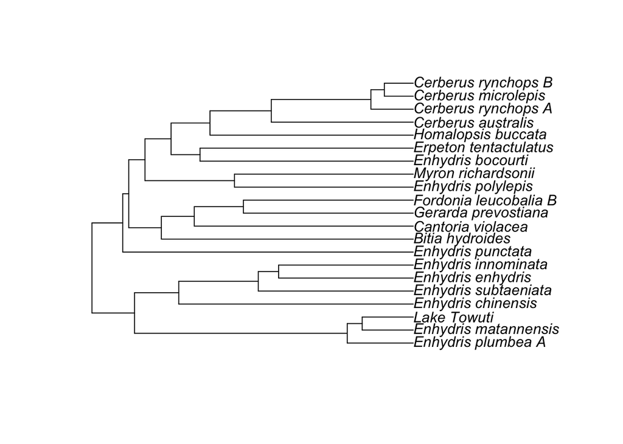

```r
setwd("/Users/michael_alfaro/Dropbox/teaching/200a 2015/tree-sims-lab/") #you need to change this to match your directory
snake_tree<-read.tree("homalops.phy")
# plot the tree
plot(snake_tree)
```

The ladderize option standardizes the drawing of trees. The command will let you save your trees as a pdf. The pdf file will be saved to your working directory.

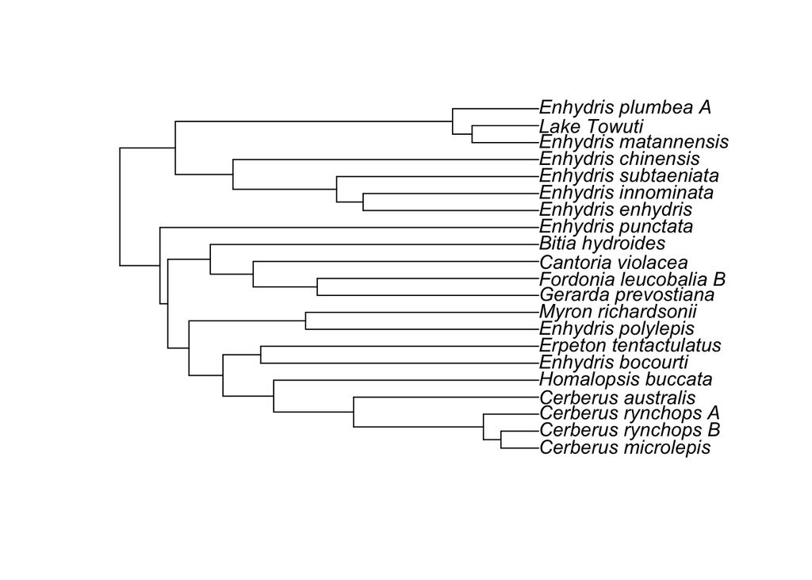

```r
plot(ladderize(snake_tree))
```

```r
pdf('snaketree.pdf')
plot(ladderize(snake_tree))
dev.off()
```

### Lineage Through time Plots

Lineage through time (ltt) plots are commonly used to visualize the accumulation of species over the history of a clade. Under a time-homogenous model (pure birth or birth death) we expect that species will accumulate with time in a log-linear manner. Let’s look at two different ways or making lineage through time plots. First we will use the ltt.plot command in APE.

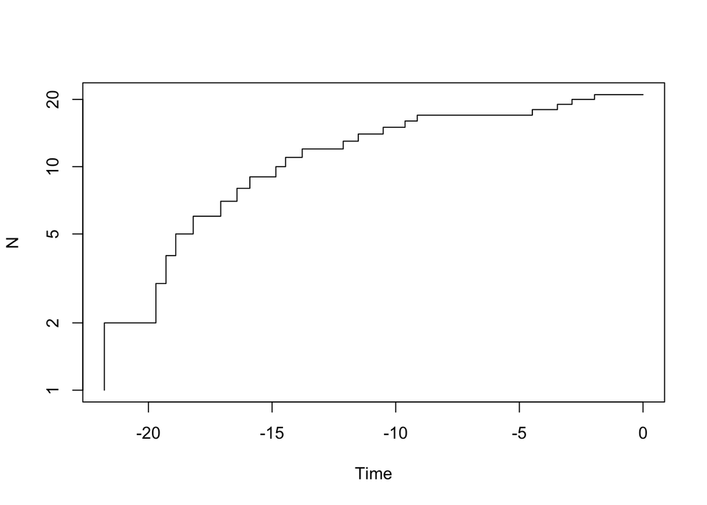

```r
ltt.plot(snake_tree, log="y")
```

Here is an example of plot commands with titles. The par command sets graphical parameters. We will use the layout option to split the output window into two rows and one column. The data() function loads example data sets.

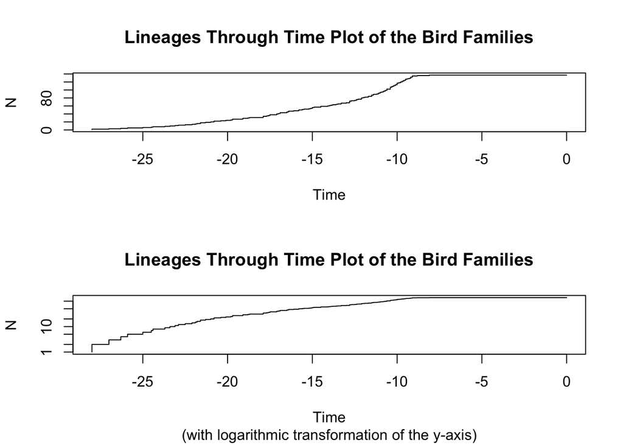

```r
layout(matrix(1:2, 2, 1))
data(bird.families)
data(bird.orders)
#plot them with titles
ltt.plot(bird.families)
title("Lineages Through Time Plot of the Bird Families")
ltt.plot(bird.families, log = "y")
title(main = "Lineages Through Time Plot of the Bird Families",
      sub = "(with logarithmic transformation of the y-axis)")
```

Now lets plot a tree and the LTT plot together layout is another command for visualizing multiple plots here we specify a plot with two rows and two columns using the matrix command

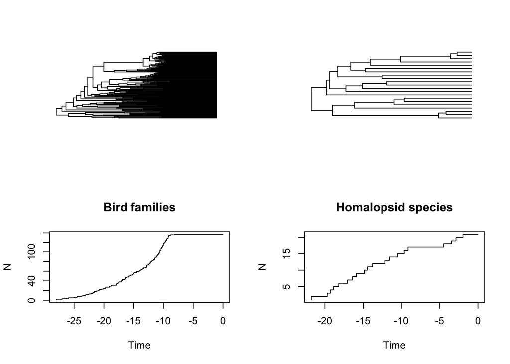

```r
layout(matrix(1:4, 2, 2))
plot(bird.families, show.tip.label = FALSE)
ltt.plot(bird.families, main = "Bird families")
plot(snake_tree, show.tip.label = FALSE)
ltt.plot(snake_tree, main = "Homalopsid species")
```

the mltt.plot command will show multiple lineage through time plots on the same figure.

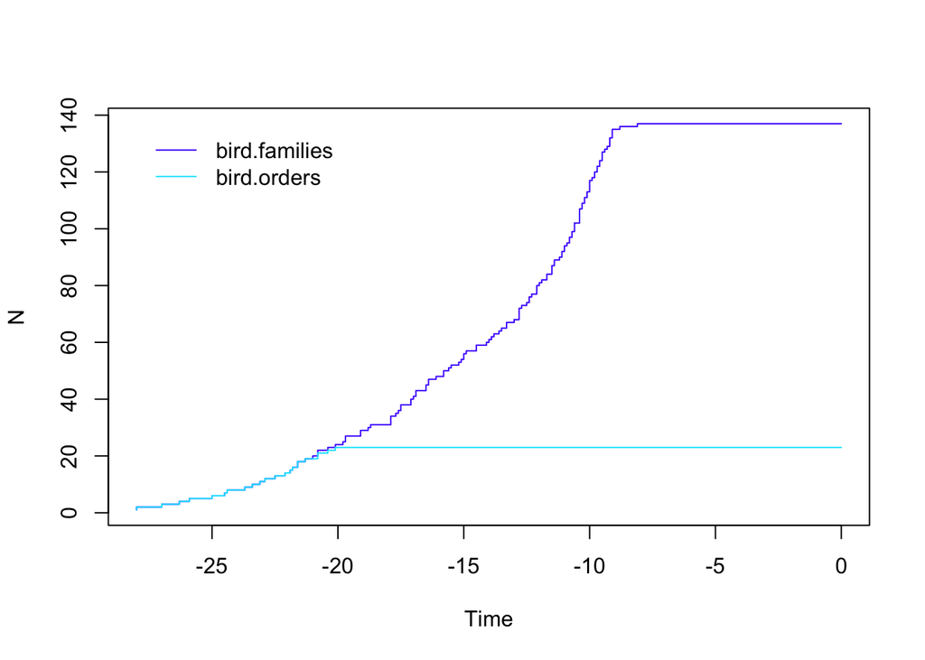

```r
layout(matrix(1))
mltt.plot(bird.families, bird.orders)
```

### LTT plots in LASER

Laser also has an ltt plotting function, but it uses the waiting times as an input file rather than the tree itself. To extract waiting times from a tree, use the getBtimes()command

```r
library(laser)
setwd("/Users/michael_alfaro/Dropbox/teaching/200a 2015/tree-sims-lab/")
snake.times<-getBtimes('homalops.phy')
```

This reads the branching times in from the tree file again. However, sometimes this is a pain because we already have the tree object in memory. We can also use the string argument to pass it a phylip tree. The write.tree() command would save string representation of the tree to the hard drive if we passed it a file name. In this case we just want to hand the string directly over to getBtimes().

```r
setwd("/Users/michael_alfaro/Dropbox/teaching/200a 2015/tree-sims-lab/")
snake_tree<-read.tree("homalops.phy")
snake.times2<-getBtimes(string = write.tree(snake_tree))
snake.times2
```

```
##  [1] 21.783281 19.698911 19.291015 18.896251 18.190025 17.078195 16.419725
##  [8] 15.900081 14.847855 14.456585 13.782375 12.123975 11.514905 10.507591
## [15]  9.624845  9.128891  4.476151  3.462541  2.871535  1.960470
```

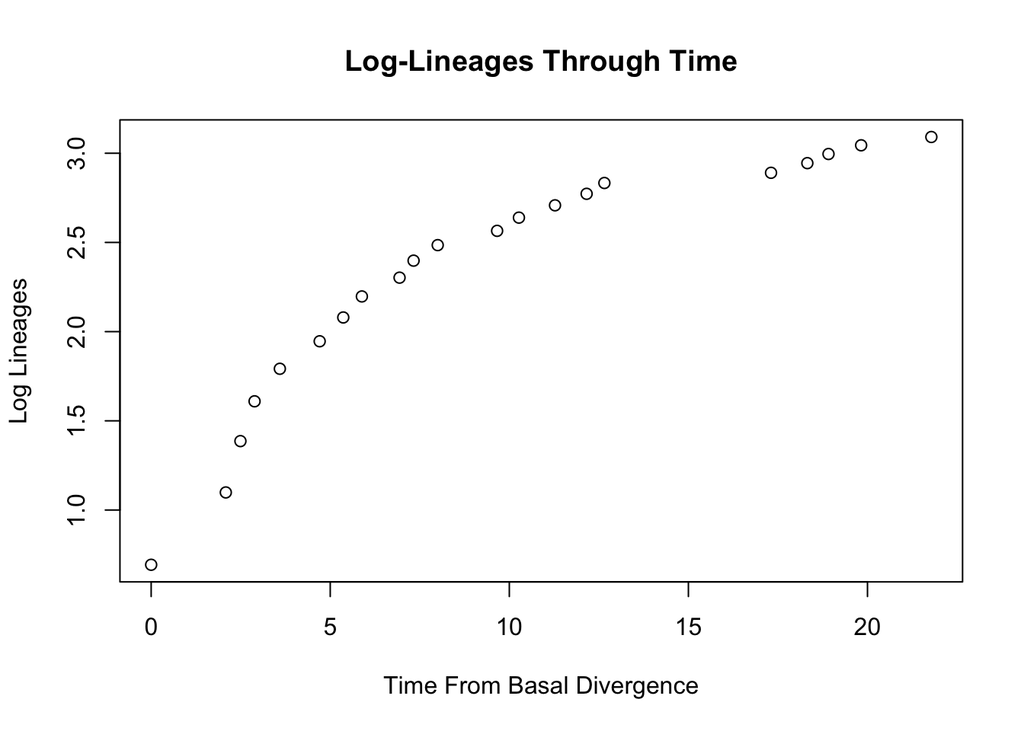

```
##  [1] 0.6931472 1.0986123 1.3862944 1.6094379 1.7917595 1.9459101 2.0794415
##  [8] 2.1972246 2.3025851 2.3978953 2.4849066 2.5649494 2.6390573 2.7080502
## [15] 2.7725887 2.8332133 2.8903718 2.9444390 2.9957323 3.0445224 3.0910425
```

```r
plotLtt(snake.times2)
```

Let’s compare both plots.

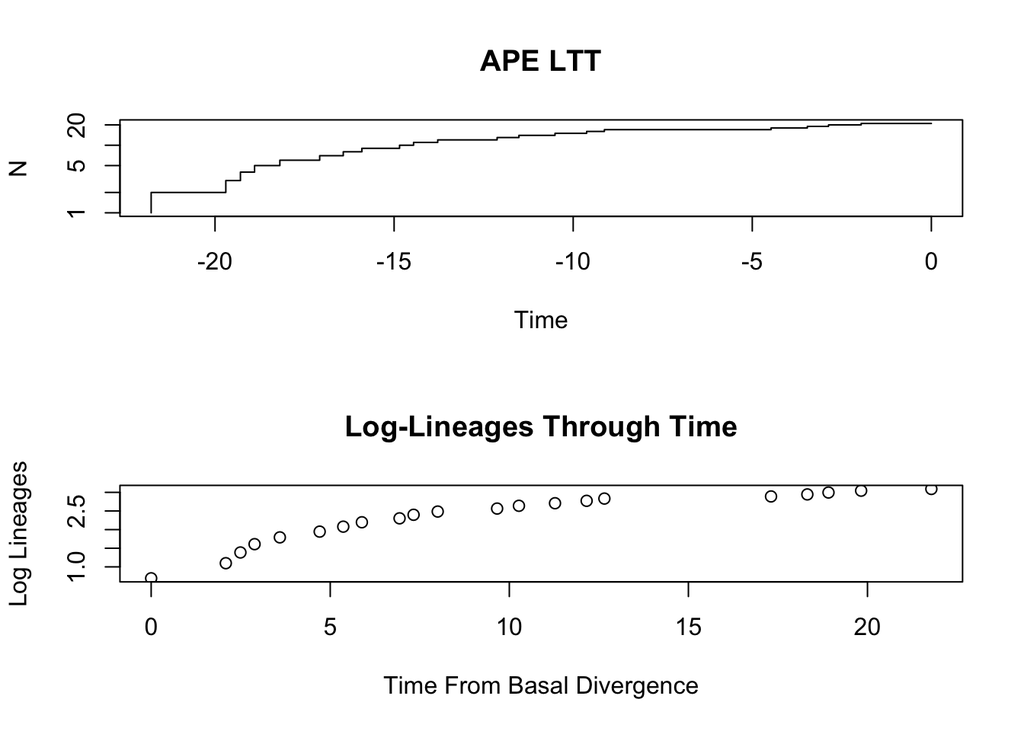

```
##  [1] 0.6931472 1.0986123 1.3862944 1.6094379 1.7917595 1.9459101 2.0794415
##  [8] 2.1972246 2.3025851 2.3978953 2.4849066 2.5649494 2.6390573 2.7080502
## [15] 2.7725887 2.8332133 2.8903718 2.9444390 2.9957323 3.0445224 3.0910425
```

```r
layout(matrix(1:2, 2,1))
ltt.plot(snake_tree, log="y", main = "APE LTT")
plotLtt(snake.times)
```

## The Gamma Statistic

Gamma is a statistic calculated from a phylogeny with branch lengths that describes the distribution of waiting times (splitting events) on the tree. Trees generated under a pure birth model are expected to have a gamma value of 0. If the gamma value of an empirical phylogeny is very different from 0, this indicates that the distribution of waiting times from the tree is unlikely to have resulted from a constant-rate pure-birth process. Negative gamma values indicate that the waiting times on the tree are more concentrated towards the root then expected under a pure birth model while positive gamma values indicate that waiting times are more concentrated towards the tips. Typically, negative gamma values are interpreted as evidence that the rate of diversification in a tree was fastest early in the history of the clade and has slowed through time. Since a slowing of diversification rate through time is predicted by several macroevolutionary scenarios of key innovation and adaptive radiation, negative gamma values are often interpreted as evidence supporting the adaptive radiation of a clade. Positive gamma values are generally not considered to be strong evidence for increasing diversification towards the present because it is difficult to disentangle the confounding influences of increasing speciation rate, decreasing extinction rate, and the ‘pull of the present’ (a tendency to underestimate extinction rates in younger taxa because they have not had enough time to go extinct).

Ape has a function, gammaStat() that will calculate gamma for a tree.

```r
snake_gamma <- gammaStat(snake_tree)
snake_gamma
```

```
## [1] -3.241085
```

```r
##mccrTest(CladeSize, NumberMissing, NumberOfReps, ObservedGamma = NULL, fname=NULL)
mccrTest(34, 13, 100, ObservedGamma=snake_gamma)->mccrResults
mccrResults
```

```
## $null.gamma
##   [1] -0.142161055 -0.671472587 -0.505836471 -2.428331715 -1.745048650
##   [6] -0.180562725  0.402199831 -0.924548234 -0.158628958 -0.297777990
##  [11] -1.111064184 -0.867592372 -0.135358798  0.849699018  0.134415608
##  [16]  0.555351515  0.229973934  0.068918453 -1.302095880  1.208889220
##  [21] -1.836839206 -1.831517334 -0.238708800 -0.673378596 -2.073985075
##  [26] -2.071793232 -0.316832076 -2.383220590 -1.309510584  1.264311956
##  [31] -1.962159089 -1.236114222 -0.443691204  0.272553401 -0.910925961
##  [36] -1.436615844  0.775406628 -0.337977060  0.034158554  0.076706375
##  [41] -0.476918979  0.149824895 -0.319352855 -0.576832088  0.213989236
##  [46] -0.810264271 -1.681407168 -1.678990159 -0.602712404 -0.335986757
##  [51] -0.490647662 -1.752662008 -1.071442137 -1.477685676  0.110850308
##  [56] -0.175302737 -1.951474938  0.823747898 -0.470215137 -1.080112463
##  [61] -1.614229994  0.354469216 -0.007928526 -0.622966689  1.321178063
##  [66] -1.789360762  0.118058879 -1.601134937 -0.785187744 -0.096390463
##  [71] -1.165347971  0.051866706 -1.143111111 -1.299430880 -0.075809626
##  [76] -0.509610138 -0.822517499 -1.214391935 -0.247094297 -0.469854556
##  [81]  0.034244486 -1.198235851  0.791406566 -3.281156843 -0.903391723
##  [86] -1.506709155  0.440712820 -1.605204221 -0.315587452 -0.227401002
##  [91] -2.183270478 -0.606328160 -0.994825924  0.321275436 -1.199041115
##  [96] -1.840125960 -1.538585699 -0.542045615  0.160092943  0.755962036
##
## $critical.value
## [1] -2.071903
##
## $p.value
## [1] 0.01980198
```

```r
age <- 22
richness <- 34
snakebirth =  log(richness)/age
snakebirth
```

```
## [1] 0.1602891
```

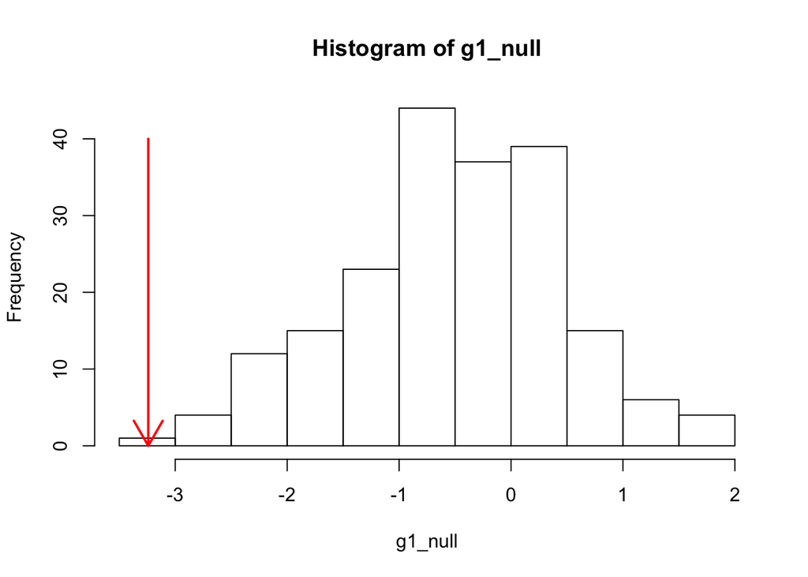

```r
#this simulates gamma values when trees are undersampled.
#we will grow trees with n=34 and prune them down to 13 taxa

num_simulations<-200 #number of simulations
g1_null<-numeric(num_simulations) #g1_null will hold the simulated gamma values
for(i in 1:num_simulations) {
  sim.bdtree(snakebirth, d=0, stop = "taxa", n=34)->sim_tree
  drop.random(sim_tree, 13)->prune # prune down to the # of taxa in the phylogeny
    gammaStat(prune)->g1_null[i]
}
# create a histogram of the null distribution
hist(g1_null)

#arrow indicates where the observed gamma falls in the null you just generated
arrows(snake_gamma, 40, snake_gamma, 0, col="red", lwd=2)
```

```r
# Which of the null values are smaller (more negative) than the data?
smallerNull<-g1_null<=snake_gamma
# How many TRUEs are there?
count<-sum(smallerNull)

# finally, what is the p-value?
mccr_pval<-(count+1)/(num_simulations+1)
mccr_pval
```

```
## [1] 0.004975124
```

## Fitting Diversification Models to Branching Times

The MCCR test allowed us to reject a model of constant diversification through time in favor of one where early rates where faster than later rates. However this exercise did not attempt to distinguish between different models of diversification. Now we will use the LASER package to look more closely at patterns of diversification in homalopsids by comparing the fit of explicit evolutionary models.

Laser works with the branching times rather than the tree, so we need to extract those from the treefile.

```r
#setwd("/Users/michaelalfaro/Dropbox/teaching/200a 2014/diversification") #you need to change this to match your directory
snake.times<-getBtimes('homalops.phy')
```

Next we will fit a series of models to these branching times to see if any are especially better than the others. The density dependent models are both consistent with the adaptive radiation hypotheses as they model the rate of speciation as a function of the number of species.

- pb: pure birth
- bd: birth-death
- DDL: density dependent, logistic
- DDX: density dependent, exponential
- SPVAR: exponentially declining speciation, constant extinction rate
- EXVAR: constant speciation, exponentially increasing extinction rate
- BOTHVAR: variable speciation and extinction

For each model we will calculate the AIC score and save it to a table. Once all models have been evaluated, we will calculate deltaAIC scores and see if the best model is substantially better than any other models in our pool.

```r
pb<-pureBirth(snake.times) #pb
aic.pb<-pb$aic#store aic score
bd<-bd(snake.times) # birth-death
aic.bd<-bd$aic #store aic
ddl<-DDL(snake.times) # logistic density dependent diversification
aic.ddl<-ddl$aic
ddx<-DDX(snake.times) # exponential density dependent diversification
aic.ddx<-ddx$aic
#the MCCR test above cannot discriminate between early rapid speciation and early slow extinction.
#these models allow those to scenarios to be compared
spvar<-fitSPVAR(snake.times, init=c(2, .2, .1))#variable speciation
aic.spvar<-spvar$aic
exvar<-fitEXVAR(snake.times, init=c(.3, .01, 1))#variable extinction
aic.exvar<-exvar$aic
both<-fitBOTHVAR(snake.times, init=c(.3, .5, .1, .5))#variable extinction and speciation
aic.both<-both$aic

#make a table and compare them all
aic.all<-cbind(aic.pb, aic.bd, aic.ddl, aic.ddx, aic.spvar, aic.exvar, aic.both)
foo<-function(x) x-x[which(x==min(x))] #quick function to compare all models to the model with lowest aic score
daic<-t(apply(aic.all, 1, foo))#apply that function to everything in aic.all
cat("Table of delta-aic values; zero - best model\n")
```

```
## Table of delta-aic values; zero - best model
```

```r
print(daic, digits=2)
```

```
##    aic.pb aic.bd aic.ddl aic.ddx aic.spvar aic.exvar aic.both
## LH     12     14       0     1.8       4.5        17      6.6
```

## Exercise 5

What would you conclude from this table? How is this different from what you can say after the MCCR test?

## Exercise 6.

Calculate the gamma statistic for the balistoid tree and comment on whether this clade shows evidence for rates that have slowed through time. Fit the laser models to this tree and explain whether balistoid diversification is consistent with density dependent diversification. fit laser models to balistoid tree

## Additional simulations on gamma statistic and the Colless tree imbalance statistic

This exercise comes from the Recology page: http://recology.info/2012/10/phylogenetic-tree-balance/

Simulate a bunch of trees and calculate gamma for them.

```r
library(ape)
library(phytools)
numtrees <- 1000
trees <- pbtree(n = 50, nsim = numtrees, ape = F)
```

Two functions here. The first calcuates Colless or gamma.The second sets up a background for ggplot2

```r
  foo <- function(tree, metric = "colless") {
      if (metric == "colless") {
          #xx <- as.treeshape(x)  # convert to apTreeshape format
          colless(tree)
          #colless(xx, norm = "yule")  # calculate colless' metric
      } else if (metric == "gamma") {
          gammaStat(tree)
      } else stop("metric should be one of colless or gamma")
  }

 theme_myblank <- function() {
     stopifnot(require(ggplot2))
     theme_blank <- ggplot2::theme_blank
     ggplot2::theme(panel.grid.major = element_blank(), panel.grid.minor = element_blank(),
         panel.background = element_blank(), plot.background = element_blank(),
         axis.title.x = element_text(colour = NA), axis.title.y = element_blank(),
         axis.text.x = element_blank(), axis.text.y = element_blank(), axis.line = element_blank(),
         axis.ticks = element_blank())
 }
```

OK now lets do some work.

```r
library(plyr)
library(apTreeshape)
```

```r
colless_df <- ldply(trees, foo, metric = "colless")  # calculate metric for each tree

#calculate cutoffs
col_percent_low <- round(length(colless_df[colless_df$V1 < -0.7, "V1"])/numtrees, 2) * 100
col_percent_high <- round(length(colless_df[colless_df$V1 > 0.7, "V1"])/numtrees, 2) * 100

library(ggplot2)
```